# Lecture 8

Spatio-temporal models

Sara Martino

sara.martino@ntnu.no

Dept. of Mathematical Science, NTNU

Janine Illian

Janine.Illian@glasgow.ac.uk

University of Glasgow

Jafet Belmont

Jafet.Belmont@glasgow.ac.uk

University of Glasgow

## Motivation

- Many real-world data sets vary in both **space** and **time**.
  - Examples: rainfall, temperature, air pollution, crop yield, disease spread.
- We often want to model **how similarity (correlation)** changes across both dimensions.

**The good news** 👍

- the framework works with spatio-temporal data as well

**The bad news** 👎

- fully spatio-temporal models are complex
- model fitting can take a long time
- different types of spatio-temporal data structures lead to different types of complexities

## Complexity of spatio-temporal models

- additional dependencies: in space and time
- spatial and temporal behaviour can be *independent* on each other, or *dependent*: i.e. properties of the spatial structure vary through time (or vice versa)

Several options are available in `inlabru`

- Areal Model
- Geostatistical and Point Process models

## The Spatio-Temporal Framework

We define a stochastic process:

$$Z(s,t), \quad s \in \mathcal{S} \subset \mathbb{R}^d, \quad t \in \mathcal{T}$$

The covariance function:

$$C((s_1,t_1),(s_2,t_2)) = \text{Cov}[Z(s_1,t_1), Z(s_2,t_2)]$$

Our goal: specify $C(\cdot)$ to capture **spatial**, **temporal**, and **joint** dependencies.

## Separable and non-separable models

**Separable models**
$$C((s_1,t_1),(s_2,t_2)) = C_S(s_1,s_2) \times C_T(t_1,t_2)$$

**Interpretation:**

- Space and time act *independently*.
- Spatial correlation not dependent on time lag.

**Advantages:** 😀

- Simpler estimation.
- Fewer parameters $\rightarrow$ Easier computation.

**Disadvantages:** 😔

- Unrealistic for evolving or propagating phenomena.

**Non-Separable models**

## Separable and non-separable models

**Separable models**
$$C((s_1,t_1),(s_2,t_2)) = C_S(s_1,s_2) \times C_T(t_1,t_2)$$

**Interpretation:**

- Space and time act *independently*.
- Spatial correlation not dependent on time lag.

**Advantages:** 😀

- Simpler estimation.
- Fewer parameters $\rightarrow$ Easier computation.

**Disadvantages:** 😔

- Unrealistic for evolving or propagating phenomena.

**Non-Separable models**

$$C((s_1,t_1),(s_2,t_2)) = f(|s_2-s_1|,|t_2-t_1|)$$
**Advantages:** 😀

- More realistic for dynamic physical processes.
- Can model propagation or decay that varies over time.

**Disadvantages:** 😔

- More parameters → complex estimation.
- Need more data for estimation
- Interpretation may be less straightforward.

We here focus on **separable models**

# Areal Data

## Spatio temporal models for areal data

$\frac{\text{Number of cases } Y_{st}}{\text{Expected numer of cases }E_{st}}$ in Ohio from 1968 to 1988 (simulated data!)

Space

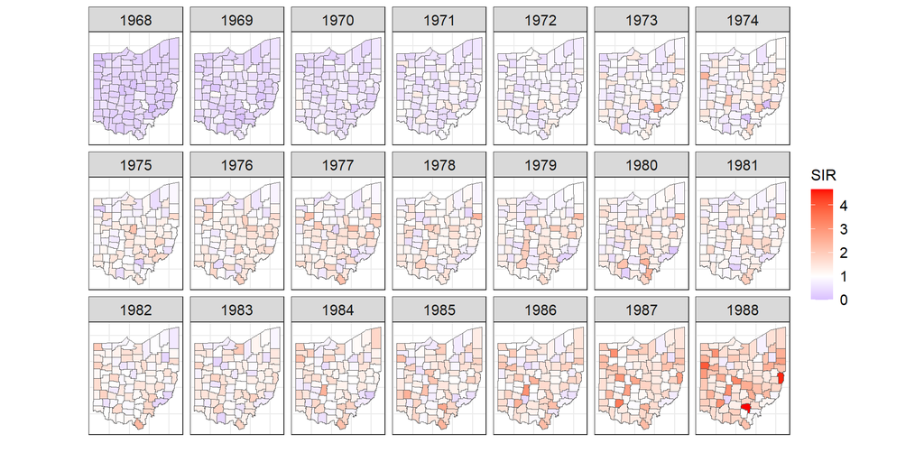

## Spatio temporal models for areal data

$\frac{\text{Number of cases } Y_{st}}{\text{Expected numer of cases }E_{st}}$ in Ohio from 1968 to 1988

Time

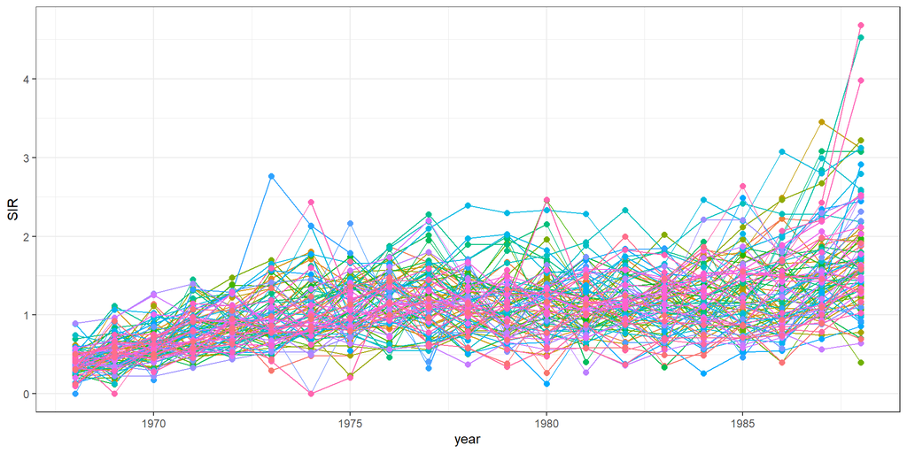

## Spatio temporal models for areal data

$\frac{\text{Number of cases } Y_{st}}{\text{Expected numer of cases }E_{st}}$ in Ohio from 1968 to 1988

Time

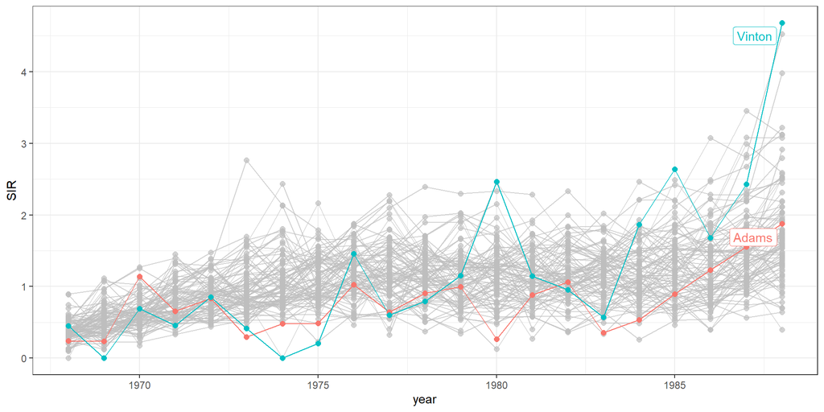

## Spatio temporal models for areal data

The observation model

$$Y_{st}|\lambda_{st}\sim\text{Poisson}(E_{st}\lambda_{st})$$

We are going to see **3 different models for the linear predictor** $\eta_{st} = \log \lambda_{st}$

1. **Model 1**: $\eta_{st} = \beta_0 + u_s + v_t$ with $u_s\sim\text{CAR}(\tau)$

   Here the time effect $v_t$ is constant w.r.t. space and the space effect $u_t$ is constant w.r.t. time.

## Model 1 - Implementation

```r
cmp_1 = ~ Intercept(1) +
  space(id_area, model = "besag", graph = g, scale.model = T) +
  time(year, model  = "rw2", scale.model = T)

lik = bru_obs(formula = Y~.,
              data = out,
              family = "poisson",
              E = E )
fit_1 = bru(cmp_1, lik)
```

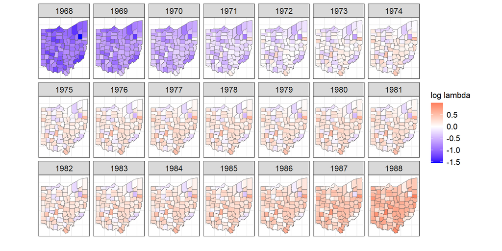

## Model 1 - Implementation

```r
cmp_1 = ~ Intercept(1) +
  space(id_area, model = "besag", graph = g, scale.model = T) +
  time(year, model  = "rw2", scale.model = T)

lik = bru_obs(formula = Y~.,
              data = out,
              family = "poisson",
              E = E )
fit_1 = bru(cmp_1, lik)
```

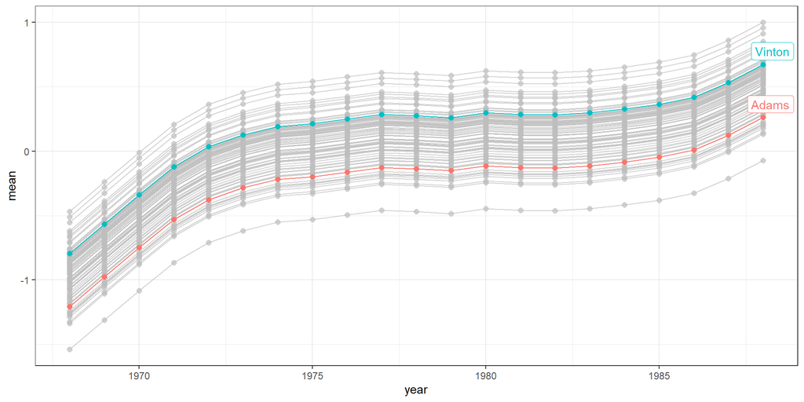

## Spatio temporal models for areal data

The observation model
$$Y_{st}|\lambda_{st}\sim\text{Poisson}(E_{st}\lambda_{st})$$

We are going to see **3 different models for the linear predictor** $\eta_{st} = \log \lambda_{st}$

1. **Model 1**: $\eta_{st} = \beta_0 + u_s + v_t$ with $u_s\sim\text{CAR}(\tau)$

   Here the time effect $v_t$ is constant w.r.t. space and the space effect $u_t$ is constant w.r.t. time.
2. **Model 2**: $\eta_{st} = \beta_0 + u_{st} + v_t$ with $u_{st}\sim\text{CAR}(\tau),\ i = 1,\dots,T$

   Here the spatial fields are different for each year, they are independent on each other.

## Model 2 - Implementation

```r
cmp_2 = ~ Intercept(1) +
  space(id_area, model = "besag", graph = g, scale.model = T,
                               replicate = id_time) +
  time(year, model  = "rw2", scale.model = T)

fit_2 = bru(cmp_2, lik)
```

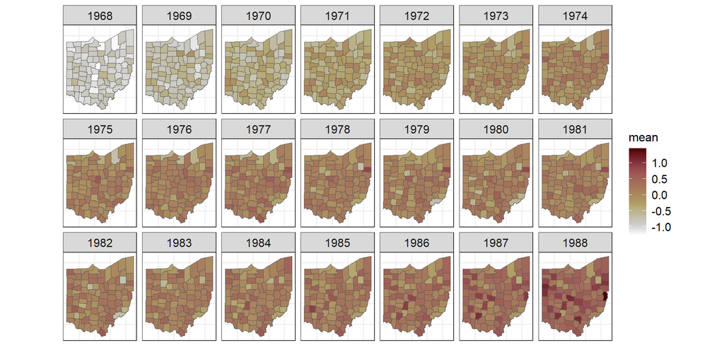

## Model 2 - Implementation

```r
cmp_2 = ~ Intercept(1) +
  space(id_area, model = "besag", graph = g, scale.model = T,
                               replicate = id_time) +
  time(year, model  = "rw2", scale.model = T)

fit_2 = bru(cmp_2, lik)
```

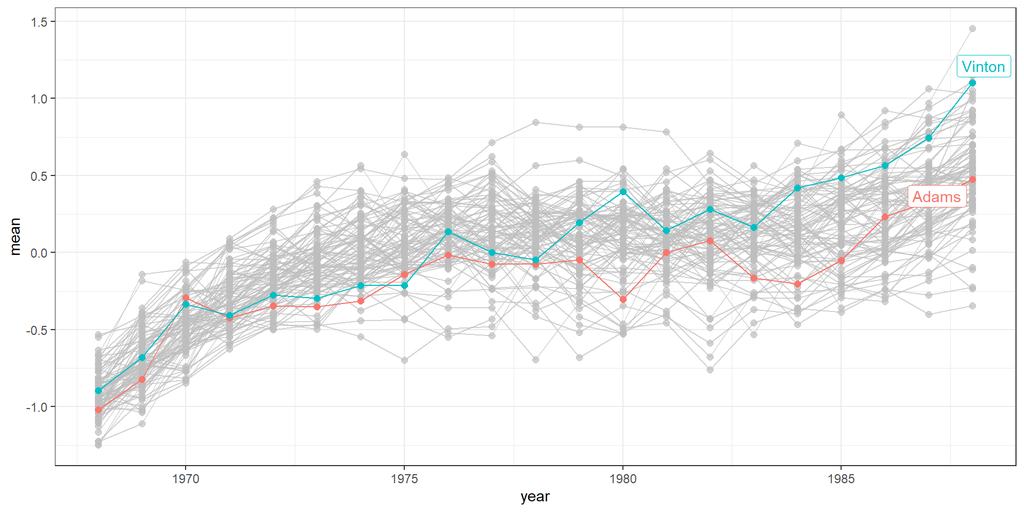

## Spatio temporal models for areal data

The observation model

$$Y_{st}|\lambda_{st}\sim\text{Poisson}(E_{st}\lambda_{st})$$

We are going to see **3 different models for the linear predictor** $\eta_{st} = \log \lambda_{st}$

1. **Model 1**: $\eta_{st} = \beta_0 + u_s + v_t$ with $u_s\sim\text{CAR}(\tau)$

   Here the time effect $v_t$ is constant w.r.t. space and the space effect $u_t$ is constant w.r.t. time.
2. **Model 2**: $\eta_{st} = \beta_0 + u_{st} + v_t$ with $u_{st}\sim\text{CAR}(\tau),\ i = 1,\dots,T$

   Here the spatial fields are different for each year, they are independent on each other.
3. **Model 3**: $\eta_{st} = \beta_0 + u_{st} + v_t$ with
   $$u_{st} = \phi u_{st-1} + w_{st}, \text{ with } w_{st}\sim\text{CAR}(\tau),\ i = 1,\dots,T$$

## Model 3 - Implementation

```r
cmp_3 = ~ Intercept(1) +
  space(id_area, model = "besag", graph = g, scale.model = T,
                               group = id_time, control.group = list(model = "ar1")) +
  time(year, model  = "rw2", scale.model = T)

fit_3 = bru(cmp_3, lik)
```

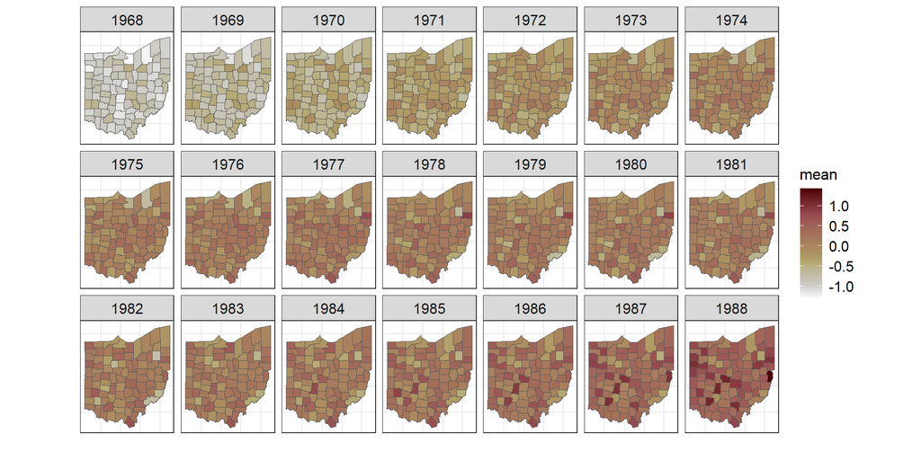

## Model 3 - Implementation

```r
cmp_3 = ~ Intercept(1) +
  space(id_area, model = "besag", graph = g, scale.model = T,
                               group = id_time, control.group = list(model = "ar1")) +
  time(year, model  = "rw2", scale.model = T)

fit_3 = bru(cmp_3, lik)
```

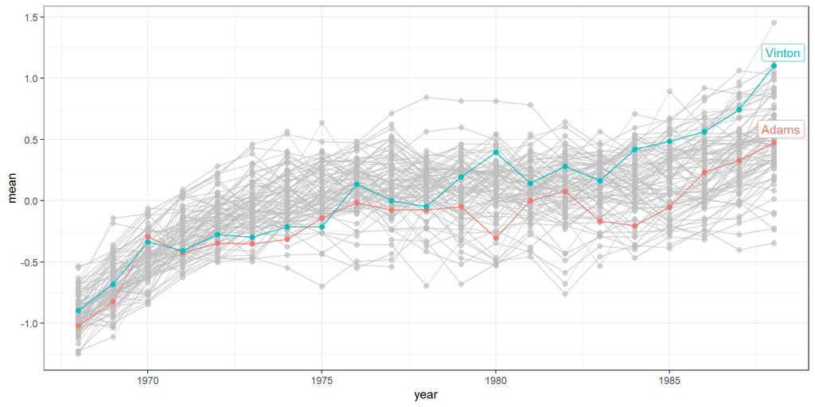

## Spatio temporal models for areal data

The observation model

$$Y_{st}|\lambda_{st}\sim\text{Poisson}(E_{st}\lambda_{st})$$

1. **Model 1**: $\eta_{st} = \beta_0 + u_s + v_t$ with $u_s\sim\text{CAR}(\tau)$
2. **Model 2**: $\eta_{st} = \beta_0 + u_{st} + v_t$ with $u_{st}\sim\text{CAR}(\tau),\ i = 1,\dots,T$
3. **Model 3**: $\eta_{st} = \beta_0 + u_{st} + v_t$ with
   $$u_{st} = \phi u_{st-1} + w_{st}, \text{ with } w_{st}\sim\text{CAR}(\tau),\ i = 1,\dots,T$$

**Compare**

- Differences between Model 2 and 3 are not evident when estimating the past, but they would give different predictions
- Model 3 in this case seem to better fit the data (*more about these measures later*)

```
    model      DIC     WAIC
1 Model 1 14886.85 18831.79
2 Model 2 12361.77 12256.53
3 Model 3 11961.12 11940.33
```

```
                     mean    sd 0.025quant 0.975quant
Precision for space 13.12  1.25      10.80      15.73
GroupRho for space   0.88  0.01       0.85       0.91
Precision for time  57.14 25.44      21.77     119.80
```

## Spatio temporal models for areal data in `inlabru`

- Models can be stuck together using either
  - `replicate` - the different *slices* are independent but share the hyperparameter
  - `group` - different dependence structures are implemented

**Types of `group` model**

```r
names(inla.models()$group)
```

```
[1] "exchangeable"    "exchangeablepos" "ar1"             "ar"
[5] "rw1"             "rw2"             "besag"           "iid"
```

**Note** The `group` and `replicate` features can be used for more than space-time modeling!